# Assignment 2: Classification

# Using Machine Learning Tools

## Overview

In this assignment, you will apply some popular machine learning techniques to the problem of classifying data from histological cell images for the diagnosis of malignant breast cancer. This will be presented as a practical scenario where you are approached by a client to solve a problem.

The main aims of this assignment are:

- to use the best practice machine learning workflow for producing a solution to a client's problem;
- to visualise and clean data;
- to train and optimise a selection of models, then choose the best;
- to obtain an unbiased measurement of the final model's performance;
- to interpret results clearly and concisely.

This assignment relates to the following ACS CBOK areas: abstraction, design, hardware and software, data and information, HCI and programming.

## General instructions

This assignment is divided into several tasks. Use the spaces provided in this notebook to answer the questions posed in each task, but feel free to add additional cells to structure your notebook. Note that some questions require writing code, some require graphical results, and some require comments or analysis as text. It is your responsibility to make sure your responses are clearly labelled and your code has been fully executed (**with the correct results displayed**) before submission!

**Do not** manually edit the data set file we have provided! For marking purposes, it's important that your code can run correctly on the original data file.

This assignment uses the standard best practice machine learning workflow, building on the first assignment and course workshops, and so less detailed instructions are provided for this assignment. You should be able to implement this workflow now without low-level guidance and a substantial portion of the marks for this assignment are associated with the appropriate choices and executing this workflow correctly and efficiently. Make sure you have clean, readable code as well as producing outputs, since your coding will also count towards the marks (however, excessive commenting is discouraged and will lose marks, so aim for a modest, well-chosen amount of comments and text in outputs).

This assignment can be solved using methods from [sklearn](https://scikit-learn.org/stable/index.html), [pandas](https://pandas.pydata.org/pandas-docs/stable/index.html), and [matplotlib](https://matplotlib.org/stable/index.html) as presented in the workshops. Other libraries should not be used (even though they might have nice functionality) and occasionally certain specific functions need to be used, which will be made clear in the instruction text. You are expected to make sure that you are using functions correctly, and you should search and carefully read the documentation if unsure.

# Scenario

A client approaches you to solve a machine learning problem for them. They run a pathology lab that processes histological images for healthcare providers and they have created a product that measures most of the same features as in the *Wisconsin breast cancer data set* though using different acquisitions and processing methods. Their method employs efficient stochastic sampling, making it much faster than existing methods, although slightly noisier. This method does not measure any of the 'worst' features that appear in the *Wisconsin Breast Cancer Data Set*. They want to be able to diagnose *malignant* cancer (and distinguish them from *benign* growths) by employing machine learning techniques, and they have asked you to implement this for them.

Their requirements are:

- 1. Have at least a 90% probability of detecting malignant cancer when it is present;
- 2. Ensure that no more than 1 in 5 healthy cases (those with benign growths) result in a false positive (labeled as malignant).

They have hand-labelled 220 samples for you, with 20 features per sample, which is all they have at the moment.

Please follow the instructions below, which will vary in level of detail.

## 1. Load data, visualise it and identify erroneous values [30%]

- Load the data from the csv file `assignment2_data_2024.csv` (found on MyUni).
- Extract the feature names and label names for use later on.
- Provide at least one text summary of the dataset. This should include key information and characteristics of the data.
- Create one graphical plot per feature. Each plot must display the feature values for the two classes (malignant and benign) separately on a single axis/panel.
- Make sure you clearly label the graphical plots with respect to feature names, axes, classes, etc.
- Identify any erroneous values in the dataset during the data visualisation or summary steps. Determine and implement, here or later, the appropriate action to handle these values (e.g., removal, correction, or none).
- Throughout this assignment, treat the *malignant* cases as the *true positive* class, following the standard convention in medicine. .

```python
# This code imports some libraries that you will need.
# You should not need to modify it, though you are expected to make other imports later in your code.

# Python ≥3.5 is required
import sys
assert sys.version_info >= (3, 5)

# Common imports
import numpy as np
import time

# Pandas for overview
import pandas as pd

# Itertools for permutations
import itertools

# Scikit-Learn ≥0.20 is required
import sklearn
assert sklearn.__version__ >= "0.20"
from sklearn.model_selection import train_test_split
from sklearn.impute import SimpleImputer
from sklearn.linear_model import LogisticRegression
from sklearn.linear_model import SGDClassifier
from sklearn.ensemble import RandomForestClassifier
from sklearn.svm import SVC
from sklearn import tree
from sklearn import svm
from sklearn.pipeline import Pipeline
from sklearn.preprocessing import StandardScaler
from sklearn.model_selection import GridSearchCV
# from sklearn.metrics import confusion_matrix
from sklearn.metrics import (accuracy_score, balanced_accuracy_score, recall_score, precision_score, roc_auc_score,
                             f1_score, confusion_matrix, fbeta_score)

# Plot setup
import matplotlib as mpl
import matplotlib.pyplot as plt
from matplotlib.ticker import MaxNLocator
mpl.rc('axes', labelsize=7)
mpl.rc('xtick', labelsize=6)
mpl.rc('ytick', labelsize=6)
mpl.rc('figure', dpi=240)
plt.close('all')

import seaborn as sns

# Hide warnings
import warnings
warnings.filterwarnings('ignore')
```

### 1.1 Load data

```python
# Your code here
# Load the data
df = pd.read_csv('assignment2_data_2024.csv')
df.head()
```

|  | label | mean radius | mean texture | mean perimeter | mean area | mean smoothness | mean compactness | mean concavity | mean concave points | mean symmetry | ... | radius error | texture error | perimeter error | area error | smoothness error | compactness error | concavity error | concave points error | symmetry error | fractal dimension error |
| --- | --- | --- | --- | --- | --- | --- | --- | --- | --- | --- | --- | --- | --- | --- | --- | --- | --- | --- | --- | --- | --- |
| 0 | malignant | 15.494653829645529 | 15.902542 | 103.008265 | 776.437239 | 0.104239 | 0.168660 | 0.170572 | 0.085668 | 0.205053 | ... | 0.653654 | 1.096678 | 4.962255 | 80.619370 | 0.006669 | 0.034950 | 0.043568 | 0.013765 | 0.024093 | 0.004928 |
| 1 | malignant | 16.229870799611437 | 18.785613 | 105.176755 | 874.712003 | 0.091843 | 0.092548 | 0.081681 | 0.053670 | 0.180435 | ... | 0.445451 | 1.043931 | 3.005373 | 50.407958 | 0.006352 | 0.019998 | 0.025324 | 0.012172 | 0.018084 | 0.003582 |
| 2 | malignant | 16.34567074196476 | 20.114076 | 107.083804 | 872.563251 | 0.099924 | 0.123799 | 0.128788 | 0.078310 | 0.189756 | ... | 0.549625 | 1.057447 | 3.643671 | 62.732851 | 0.006757 | 0.031325 | 0.034350 | 0.015150 | 0.021459 | 0.004066 |
| 3 | maligant | 13.001009157806651 | 19.876997 | 85.889775 | 541.281012 | 0.113423 | 0.173069 | 0.146214 | 0.069574 | 0.212078 | ... | 0.430693 | 1.202955 | 3.051434 | 33.614356 | 0.007930 | 0.044881 | 0.042972 | 0.014556 | 0.035670 | 0.005981 |
| 4 | malignant | 16.416060073302194 | 17.397533 | 107.857386 | 891.516818 | 0.097321 | 0.111530 | 0.125971 | 0.068575 | 0.179562 | ... | 0.525532 | 1.045900 | 3.747194 | 59.164555 | 0.008718 | 0.024231 | 0.039763 | 0.014202 | 0.019236 | 0.004115 |

5 rows × 21 columns

```python
# Extract feature names and label names
feature_names = df.columns[1:]
label_name = df.columns[0]

# Print the feature names
print('Feature names:\n', feature_names)

# Print the label name
print('Label name:', label_name)
```

```
Feature names:
 Index(['mean radius', 'mean texture', 'mean perimeter', 'mean area',
       'mean smoothness', 'mean compactness', 'mean concavity',
       'mean concave points', 'mean symmetry', 'mean fractal dimension',
       'radius error', 'texture error', 'perimeter error', 'area error',
       'smoothness error', 'compactness error', 'concavity error',
       'concave points error', 'symmetry error', 'fractal dimension error'],
      dtype='object')
Label name: label
```

```python
# Check the labels
df['label'].unique()
```

```
array(['malignant', 'maligant', 'benign'], dtype=object)
```

There is a typo error in 'malignant' label

```python
# Correct the labels and convert to numerical values
df['label'] = df['label'].map({'malignant': 1, 'maligant': 1, 'benign': 0})
```

```python
# Check the information of the data
df.info()
```

```
<class 'pandas.core.frame.DataFrame'>
RangeIndex: 220 entries, 0 to 219
Data columns (total 21 columns):
 #   Column                   Non-Null Count  Dtype
---  ------                   --------------  -----
 0   label                    220 non-null    int64
 1   mean radius              220 non-null    object
 2   mean texture             220 non-null    float64
 3   mean perimeter           220 non-null    float64
 4   mean area                220 non-null    float64
 5   mean smoothness          220 non-null    float64
 6   mean compactness         220 non-null    float64
 7   mean concavity           220 non-null    float64
 8   mean concave points      220 non-null    float64
 9   mean symmetry            220 non-null    float64
 10  mean fractal dimension   220 non-null    float64
 11  radius error             220 non-null    float64
 12  texture error            220 non-null    float64
 13  perimeter error          220 non-null    float64
 14  area error               220 non-null    float64
 15  smoothness error         220 non-null    float64
 16  compactness error        220 non-null    float64
 17  concavity error          220 non-null    float64
 18  concave points error     220 non-null    float64
 19  symmetry error           219 non-null    float64
 20  fractal dimension error  220 non-null    float64
dtypes: float64(19), int64(1), object(1)
memory usage: 36.2+ KB
```

The type of 'mean radius' column is object. There could be typo error.

```python
# Check non-numerical values in the 'mean radius' column
mean_radius = pd.to_numeric(df['mean radius'], errors='coerce')
non_numerical_values = df['mean radius'][mean_radius.isna()]
non_numerical_values
```

```
61    n12.254518716420597
Name: mean radius, dtype: object
```

There is a non-numerical value, which is a typo error.

```python
# Remove the letter 'n' from 'mean radius' and convert to numeric
df['mean radius'] = df['mean radius'].str.replace('n', '').astype(float)
```

```python
# Check the descriptive statistics
df.describe()
```

|  | label | mean radius | mean texture | mean perimeter | mean area | mean smoothness | mean compactness | mean concavity | mean concave points | mean symmetry | ... | radius error | texture error | perimeter error | area error | smoothness error | compactness error | concavity error | concave points error | symmetry error | fractal dimension error |
| --- | --- | --- | --- | --- | --- | --- | --- | --- | --- | --- | --- | --- | --- | --- | --- | --- | --- | --- | --- | --- | --- |
| count | 220.000000 | 220.000000 | 220.000000 | 220.000000 | 220.000000 | 220.000000 | 220.000000 | 220.000000 | 220.000000 | 220.000000 | ... | 220.000000 | 220.000000 | 220.000000 | 220.000000 | 220.000000 | 220.000000 | 220.000000 | 220.000000 | 219.000000 | 220.000000 |
| mean | 0.300000 | 13.686773 | 18.991963 | 89.866240 | 620.956227 | 0.096480 | 0.102879 | 0.085281 | 0.046867 | 0.181850 | ... | 0.393337 | 1.217593 | 2.775090 | 37.781034 | 0.007076 | 0.025514 | 0.031901 | 0.011762 | 0.020901 | 0.003873 |
| std | 0.459303 | 2.173254 | 1.427635 | 7.366180 | 106.419871 | 0.004961 | 0.019819 | 0.026911 | 0.012548 | 0.010816 | ... | 0.075828 | 0.210182 | 0.579317 | 9.988655 | 0.001043 | 0.007345 | 0.014102 | 0.002422 | 0.003250 | 0.001259 |
| min | 0.000000 | -14.292182 | 15.349270 | 74.690886 | -2.645499 | 0.084651 | 0.075184 | 0.050771 | 0.028701 | 0.157059 | ... | 0.298005 | 0.898026 | 2.059186 | 27.693748 | 0.004994 | 0.016907 | 0.018730 | 0.007253 | 0.016181 | 0.002631 |
| 25% | 0.000000 | 13.081811 | 17.914319 | 84.911981 | 558.731832 | 0.092797 | 0.089531 | 0.066525 | 0.038106 | 0.174944 | ... | 0.343114 | 1.073344 | 2.394331 | 31.843894 | 0.006372 | 0.020530 | 0.025373 | 0.010336 | 0.018658 | 0.003225 |
| 50% | 0.000000 | 13.640511 | 18.928256 | 88.587737 | 603.806128 | 0.096457 | 0.098517 | 0.075748 | 0.042761 | 0.180953 | ... | 0.367863 | 1.165727 | 2.610732 | 34.007608 | 0.006837 | 0.023147 | 0.028835 | 0.011357 | 0.020193 | 0.003555 |
| 75% | 1.000000 | 14.268236 | 19.995859 | 93.066393 | 655.690435 | 0.099817 | 0.113276 | 0.098826 | 0.055337 | 0.186354 | ... | 0.420514 | 1.300769 | 3.003888 | 39.042484 | 0.007675 | 0.027733 | 0.033620 | 0.012669 | 0.022195 | 0.004046 |
| max | 1.000000 | 18.200299 | 24.430831 | 121.247839 | 1103.740620 | 0.113423 | 0.192880 | 0.201971 | 0.100467 | 0.226448 | ... | 0.712896 | 2.561348 | 5.903661 | 80.619370 | 0.011088 | 0.054950 | 0.163592 | 0.026554 | 0.041861 | 0.013251 |

8 rows × 21 columns

### 1.2 Visualise

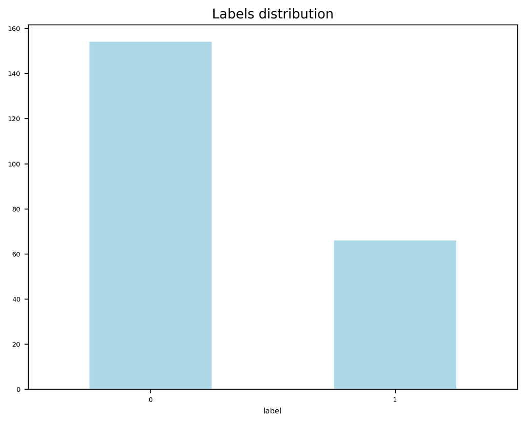

```python
# Plot the distribution of the labels
plt.figure(figsize=(8, 6))
df['label'].value_counts().plot(kind='bar', color='lightblue')
plt.gca().xaxis.set_tick_params(rotation=0)
plt.title('Labels distribution')
plt.show()
```

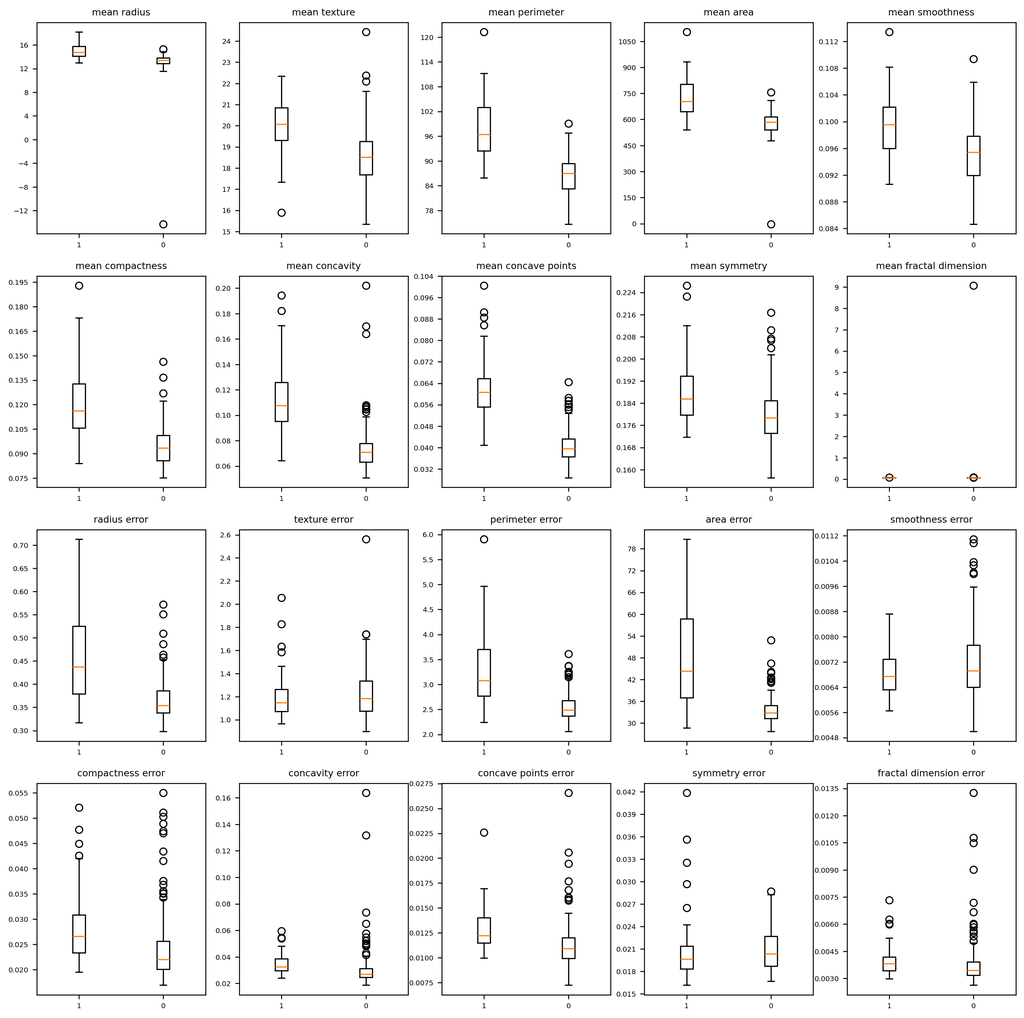

```python
# List of columns to scatter plots
col_boxes = df.columns.drop('label')

# Create a figure and axes
fig, axes = plt.subplots(4, 5, figsize=(15, 15), sharex=False)

# Flatten the axes
axes = axes.flatten()

# Plot boxplots for each column in the dataset grouped by 'label'
for i, column in enumerate(col_boxes):
    # Group by 'label' and create a list of data arrays
    grouped_data = [df[df['label'] == label][column].dropna() for label in df['label'].unique()]

    # Drop 'label' column
    grouped_data = [data for data in grouped_data if column != 'label']

    # Plot boxplot
    axes[i].boxplot(grouped_data, vert=True)
    axes[i].set_title(column, fontsize=8)
    axes[i].set_xticklabels(df['label'].unique())
    axes[i].yaxis.set_major_locator(MaxNLocator(nbins=10))

# Show plot
plt.show()
```

There are a lot of outliers. Because the sample size is small, if we modify all of them, there could be bias. I will focus on obvious outliers, such as:

- Mean radius: 1 outlier less than 8 (label 0)
- Mean perimeter: 1 outlier greater than 114 (label 1)
- Mean area: 1 outlier less than 300 (label 0)
- Mean concavity: 3 outliers greater than 0.14 (label 0)
- Mean fractal dimension: 1 outlier greater than 1 (label 0)
- Texture error: 1 outlier greater than 2 (label 0)
- Concavity error: 2 outliers greater than 0.12 (label 0)
- Concave points error: 2 outliers - 1 greater than 0.02 (label 1), 1 greater than 0.0225 (label 0)

```python
# Create a function to replace outliers with NaN
def replace_outliers_with_nan(df, col, label, comparison, value):
    if comparison == '<':
        df.loc[(df[col] < value) & (df['label'] == label), col] = np.nan
    elif comparison == '>':
        df.loc[(df[col] > value) & (df['label'] == label), col] = np.nan
    else:
        raise ValueError('Comparison must be either "<" or ">"')
```

```python
# Replace outliers with NaN
outliers = [('mean radius', 0, '<', 8),
            ('mean perimeter', 1, '>', 114),
            ('mean area', 0, '<', 300),
            ('mean area', 1, '>', 1050),
            ('mean concavity', 0, '>', 0.14),
            ('mean fractal dimension', 0, '>', 1),
            ('texture error', 0, '>', 2),
            ('concavity error', 0, '>', 0.12),
            ('concave points error', 1, '>', 0.02),
            ('concave points error', 0, '>', 0.0225)]

for col, label, comparison, value in outliers:
    replace_outliers_with_nan(df, col, label, comparison, value)
```

## 2. Prepare data and models, and make baseline measurements [20%]

- Split data into appropriate sets using the `stratify` option to obtain consistent proportions of classes in each set.
- Decide on appropriate pre-processing steps for the data.
- Implement a *very* simple baseline model that makes purely random predictions of the class.
- Measure the baseline performance with the following metrics:
  - accuracy
  - balanced accuracy: accounts for imblanaced datasets, defined as *(sensitivity + specificity)/2*
  - recall
  - precision
  - auc
  - f1score
  - fbeta_scores with beta=0.1
  - fbeta_score with beta=10
- Also display a confusion matrix for the baseline predictions.
- As a second baseline, implement an SGD classifier and fit it once (without hyper-parameter optimisation) and then display the same performance metrics and a confusion matrix for its results.

```python
# Some helpful code that you can use if you wish (or not)
from sklearn.metrics import fbeta_score, make_scorer

f10_scorer = make_scorer(fbeta_score, beta=10)
f01_scorer = make_scorer(fbeta_score, beta=0.1)

def f10_score(yt,yp):
    return fbeta_score(yt, yp, beta=10)

def f01_score(yt,yp):
    return fbeta_score(yt, yp, beta=0.1)
```

```python
# Load data
data = df.copy()

# Split data into training, validation and testing sets
bigtrain_set, test_set = train_test_split(data, test_size=0.2, stratify=data['label'], random_state=42)
X_bigtrain = bigtrain_set.drop('label', axis=1)
y_bigtrain = bigtrain_set['label']
X_test = test_set.drop('label', axis=1)
y_test = test_set['label']
train_set, val_set = train_test_split(bigtrain_set, test_size=0.2, stratify=bigtrain_set['label'], random_state=42)
X_train = train_set.drop('label', axis=1)
y_train = train_set['label']
X_val = val_set.drop('label', axis=1)
y_val = val_set['label']
```

```python
# Create preprocessing pipeline
preprocessor = Pipeline([('imputer', SimpleImputer(strategy='mean')),
                         ('scaler', StandardScaler())])
```

### 2.1 Random Classifier

```
Random Classifier model metrics:
accuracy: 0.3888888888888889
balanced_accuracy: 0.38181818181818183
recall: 0.36363636363636365
precision: 0.21052631578947367
auc: 0.38181818181818183
f1_score: 0.26666666666666666
fbeta_score (beta=0.1): 0.21140763997906856
fbeta_score (beta=10): 0.3610366398570152
confusion_matrix: [[10 15]
 [ 7  4]]
```

[figure not shown]

```python
# Create a function to random classifier model
def random_classifier(X):
    np.random.seed(42)
    y_pred = np.random.randint(2, size=len(X))
    return y_pred

# Calculate performance metrics for the random classifier model
y_pred_rc = random_classifier(X_val)

# Calculate performance metrics for the logistic regression model
print('Random Classifier model metrics:')
print("accuracy:", accuracy_score(y_val, y_pred_rc))
print("balanced_accuracy:", balanced_accuracy_score(y_val, y_pred_rc))
print("recall:", recall_score(y_val, y_pred_rc))
print("precision:", precision_score(y_val, y_pred_rc))
print("auc:", roc_auc_score(y_val, y_pred_rc))
print("f1_score:", f1_score(y_val, y_pred_rc))
print("fbeta_score (beta=0.1):", fbeta_score(y_val, y_pred_rc, beta=0.1))
print("fbeta_score (beta=10):", fbeta_score(y_val, y_pred_rc, beta=10))

cm = confusion_matrix(y_val, y_pred_rc)
print("confusion_matrix:", cm)

plt.figure(figsize=(8, 6))
sns.heatmap(cm, annot=True, cmap='Blues', fmt='g',
            xticklabels=['Malignant', 'Benign'],
            yticklabels=['Malignant', 'Benign'])
plt.xlabel('Predicted')
plt.ylabel('True')
plt.title('Confusion Matrix')
plt.show()
```

### 2.2 SGD Classifier

```python
# Create a pipeline for SGD classifier
sgd_pipeline = Pipeline([
    ('preprocessor', preprocessor),
    ('classifier', SGDClassifier(random_state=42))
])

# Fit the SGD classifier pipeline
sgd_pipeline.fit(X_train, y_train)
y_pred_sgd = sgd_pipeline.predict(X_val)

# Calculate performance metrics for the SGD classifier
print('SGD Classifier model metrics:')
print("accuracy:", accuracy_score(y_val, y_pred_sgd))
print("balanced_accuracy:", balanced_accuracy_score(y_val, y_pred_sgd))
print("recall:", recall_score(y_val, y_pred_sgd))
print("precision:", precision_score(y_val, y_pred_sgd))
print("auc:", roc_auc_score(y_val, y_pred_sgd))
print("f1_score:", f1_score(y_val, y_pred_sgd))
print("fbeta_score (beta=0.1):", fbeta_score(y_val, y_pred_sgd, beta=0.1))
print("fbeta_score (beta=10):", fbeta_score(y_val, y_pred_sgd, beta=10))

cm = confusion_matrix(y_val, y_pred_sgd)
print("confusion_matrix:", cm)

plt.figure(figsize=(8, 6))
sns.heatmap(cm, annot=True, cmap='Blues', fmt='g',
            xticklabels=['Malignant', 'Benign'],
            yticklabels=['Malignant', 'Benign'])
plt.xlabel('Predicted')
plt.ylabel('True')
plt.title('Confusion Matrix')
plt.show()
```

[output not shown]

```
SGD Classifier model metrics:
accuracy: 0.9444444444444444
balanced_accuracy: 0.9345454545454546
recall: 0.9090909090909091
precision: 0.9090909090909091
auc: 0.9345454545454546
f1_score: 0.9090909090909091
fbeta_score (beta=0.1): 0.9090909090909091
fbeta_score (beta=10): 0.9090909090909091
confusion_matrix: [[24  1]
 [ 1 10]]
```

## 3. Model Optimisation [40%]

### 3.1 Performance metric

Choose one performance metric from the above set. State your choice and explain why you chose it. [50 words maximum]

```python
# I choose the F1 score to compare models because it balances precision and recall, making it ideal for imbalanced datasets. The F1 score is a harmonic mean of
# precision and recall, providing a single score that balances the tradeoff between precision and recall. Hence, it is a reliable measure of model performance.
```

### 3.2 Hyper-parameter optimisation

- Perform a hyper-parameter optimisation (using appropriate methods) on three models:
  - SGD Classifer
  - SVM
  - One other model of your choice
- Display the results of each model (including confusion matrices) and choose the best model.
- Choose the best model and display the final results of this model.

#### 3.2.1 SGD Classifier

```python
# Define the parameter grids for each model
param_grid_sgd = {
    'classifier__alpha': [0.0001, 0.001, 0.01],
    'classifier__loss': ['hinge', 'log'],
    'classifier__penalty': ['l2', 'l1', 'elasticnet']
}

# Create pipelines for each model
pipeline_sgd = Pipeline([
    ('preprocessor', preprocessor),
    ('classifier', SGDClassifier(random_state=42))
])

# Perform grid search for each model
grid_sgd = GridSearchCV(pipeline_sgd, param_grid_sgd, cv=5, scoring='f1', refit=True)

# Fit the models
grid_sgd.fit(X_train, y_train)

# Get the best parameters with best F1 score
best_params_sgd = grid_sgd.best_params_
best_score_sgd = grid_sgd.best_score_
best_model_sgd = grid_sgd.best_estimator_

# Print the results
print('SGD Classifier model:')
print("Best parameters:", best_params_sgd)
print("Best F1 score:", best_score_sgd)

# Retrain the best model on the training set
best_model_sgd.fit(X_train, y_train)

# Predict on the validation set
y_pred_sgd = best_model_sgd.predict(X_val)

# Calculate performance metrics for each model
cm_sgd = confusion_matrix(y_val, y_pred_sgd)
print("confusion_matrix:", cm_sgd)

plt.figure(figsize=(8, 6))
sns.heatmap(cm_sgd, annot=True, cmap='Blues', fmt='g',
            xticklabels=['Malignant', 'Benign'],
            yticklabels=['Malignant', 'Benign'])
plt.xlabel('Predicted')
plt.ylabel('True')
plt.title('Confusion Matrix')
plt.show()
```

[output not shown]

```
SGD Classifier model:
Best parameters: {'classifier__alpha': 0.001, 'classifier__loss': 'hinge', 'classifier__penalty': 'l1'}
Best F1 score: 0.9358730158730157
confusion_matrix: [[24  1]
 [ 1 10]]
```

### 3.2.2 SVM

```python
# Define the parameter grids for each model
param_grid_svm = {
    'classifier__C': [0.1, 1, 10, 100],
    'classifier__gamma': [1, 0.1, 0.01, 0.001],
    'classifier__kernel': ['linear', 'rbf', 'poly', 'sigmoid']
}

# Create pipelines for each model
pipeline_svm = Pipeline([
    ('preprocessor', preprocessor),
    ('classifier', SVC(random_state=42))
])

# Perform grid search for each model
grid_svm = GridSearchCV(pipeline_svm, param_grid_svm, cv=5, scoring='f1', refit=True)

# Fit the models
grid_svm.fit(X_train, y_train)

# Get the best parameters with best F1 score
best_params_svm = grid_svm.best_params_
best_score_svm = grid_svm.best_score_
best_model_svm = grid_svm.best_estimator_

# Print the results
print('SVM model:')
print("Best parameters:", best_params_svm)
print("Best F1 score:", best_score_svm)

# Retrain the best model on the training set
best_model_svm.fit(X_train, y_train)

# Predict on the validation set
y_pred_svm = best_model_svm.predict(X_val)

# Calculate performance metrics for each model
cm_svm = confusion_matrix(y_val, y_pred_svm)
print("confusion_matrix:", cm_svm)

plt.figure(figsize=(8, 6))
sns.heatmap(cm_svm, annot=True, cmap='Blues', fmt='g',
            xticklabels=['Malignant', 'Benign'],
            yticklabels=['Malignant', 'Benign'])
plt.xlabel('Predicted')
plt.ylabel('True')
plt.title('Confusion Matrix')
plt.show()
```

[output not shown]

```
SVM model:
Best parameters: {'classifier__C': 10, 'classifier__gamma': 1, 'classifier__kernel': 'linear'}
Best F1 score: 0.9410130718954248
confusion_matrix: [[24  1]
 [ 1 10]]
```

### 3.2.3 Random Forest

```python
# Define the parameter grids for each model
param_grid_rf = {
    'classifier__n_estimators': [50, 100, 200],
    'classifier__max_depth': [None, 10, 20],
    'classifier__max_features': ['auto', 'sqrt', 'log2']
}

# Create pipelines for each model
pipeline_rf = Pipeline([
    ('preprocessor', preprocessor),
    ('classifier', RandomForestClassifier(random_state=42))
])

# Perform grid search for each model
grid_rf = GridSearchCV(pipeline_rf, param_grid_rf, cv=5, scoring='f1', refit=True)

# Fit the models
grid_rf.fit(X_train, y_train)

# Get the best parameters with best F1 score
best_params_rf = grid_rf.best_params_
best_score_rf = grid_rf.best_score_
best_model_rf = grid_rf.best_estimator_

# Print the results
print('Random Forest model:')
print("Best parameters:", best_params_rf)
print("Best F1 score:", best_score_rf)

# Retrain the best model on the training set
best_model_rf.fit(X_train, y_train)

# Predict on the validation set
y_pred_rf = best_model_rf.predict(X_val)

# Calculate performance metrics for each model
cm_rf = confusion_matrix(y_val, y_pred_rf)
print("confusion_matrix:", cm_rf)

plt.figure(figsize=(8, 6))
sns.heatmap(cm_rf, annot=True, cmap='Blues', fmt='g',
            xticklabels=['Malignant', 'Benign'],
            yticklabels=['Malignant', 'Benign'])
plt.xlabel('Predicted')
plt.ylabel('True')
plt.title('Confusion Matrix')
plt.show()
```

[output not shown]

```
Random Forest model:
Best parameters: {'classifier__max_depth': None, 'classifier__max_features': 'sqrt', 'classifier__n_estimators': 50}
Best F1 score: 0.8641795665634675
confusion_matrix: [[24  1]
 [ 1 10]]
```

```python
# Determine the best model based on f1 score
best_model = max([('SGD Classifier', best_params_sgd, best_score_sgd, best_model_sgd),
                  ('SVM', best_params_svm, best_score_svm, best_model_svm),
                  ('Random Forest', best_params_rf, best_score_rf, best_model_rf)],
                  key=lambda x: x[2])

# Print the best model
print('Best model:', best_model[0])
print('Best parameters:', best_model[1])
print('Best F1 score:', best_model[2])
```

```
Best model: SVM
Best parameters: {'classifier__C': 10, 'classifier__gamma': 1, 'classifier__kernel': 'linear'}
Best F1 score: 0.9410130718954248
```

```python
# Retrain the best model on the entire training set
best_model[3].fit(X_bigtrain, y_bigtrain)

# Predict on the test set
y_test_pred = best_model[3].predict(X_test)

# Calculate performance metrics for the best model
print("accuracy:", accuracy_score(y_test, y_test_pred))
print("balanced_accuracy:", balanced_accuracy_score(y_test, y_test_pred))
print("recall:", recall_score(y_test, y_test_pred))
print("precision:", precision_score(y_test, y_test_pred))
print("auc:", roc_auc_score(y_test, y_test_pred))
print("f1_score:", f1_score(y_test, y_test_pred))
print("fbeta_score (beta=0.1):", fbeta_score(y_test, y_test_pred, beta=0.1))
print("fbeta_score (beta=10):", fbeta_score(y_test, y_test_pred, beta=10))

cm_best = confusion_matrix(y_test, y_test_pred)
print("confusion_matrix:", cm_rf)

plt.figure(figsize=(8, 6))
sns.heatmap(cm_rf, annot=True, cmap='Blues', fmt='g',
            xticklabels=['Malignant', 'Benign'],
            yticklabels=['Malignant', 'Benign'])
plt.xlabel('Predicted')
plt.ylabel('True')
plt.title('Confusion Matrix')
plt.show()
```

[output not shown]

```
accuracy: 0.9318181818181818
balanced_accuracy: 0.9069478908188586
recall: 0.8461538461538461
precision: 0.9166666666666666
auc: 0.9069478908188586
f1_score: 0.88
fbeta_score (beta=0.1): 0.9159109645507006
fbeta_score (beta=10): 0.8467987804878049
confusion_matrix: [[24  1]
 [ 1 10]]
```

### 3.3 Final results

From the final results calculate the *probability* that a sample from a person with a malignant tumour is given a result that they do not have cancer.

```python
# Calculate the probability of a person with a malignant tumour being misclassified as no cancer
cm = cm_best
fn = cm[1, 0]  # False Negatives
tp = cm[1, 1]  # True Positives
prob = fn / (fn + tp)

print(f'The probability of a person with a malignant tumour being misclassified as no cancer: {prob:.4f}')
```

```
The probability of a person with a malignant tumour being misclassified as no cancer: 0.1538
```

## 4. Decision Boundaries [10%]

- To finish up, the client wants a visualisation of how the final model is working and your line manager has asked you to show some of the decision boundaries.
- The client also wants to know if your method has met their performance specifications.
- Follow the next three steps (4.1, 4.2 and 4.3) to do these things.

### 4.1 Discriminative features

Although it is only possible to know the true usefulness of a feature when you've combined it with others in a machine learning method, it is still helpful to have some measure for how discriminative each feature is on its own. One common method for doing this is to calculate a T-score (often used in statistics, and in the LDA machine learning method) for each feature.

The formula for the T-score is:

*(mean(x2) - mean(x1))/(0.5*(stddev(x2) + stddev(x1)))*

where x1 and x2 are the feature values corresponding to the two classes. Large values for the T-score (either positive or negative) indicate discriminative ability.

**Calculate the T-score for each feature and print out the best 4 features according to this score.**

```python
# Calculate the T-score for each feature
class_0 = X_test[y_test == 0]
class_1 = X_test[y_test == 1]

t_scores = []
for feature in X_test.columns:
    mean_0 = np.mean(class_0[feature])
    mean_1 = np.mean(class_1[feature])
    stddev_0 = np.std(class_0[feature])
    stddev_1 = np.std(class_1[feature])
    t_score = (mean_1 - mean_0) / (0.5 * (stddev_1 + stddev_0))
    t_scores.append((feature, t_score))

t_scores_sorted = sorted(t_scores, key=lambda x: abs(x[1]), reverse=True)
top_4_features = t_scores_sorted[:4]

print("Top 4 discriminative features based on T-score:")
for feature, score in top_4_features:
    print(f"{feature}: {score}")

top_4_feature_names = [feature for feature, _ in top_4_features]
```

```
Top 4 discriminative features based on T-score:
mean perimeter: 2.680681846867704
mean area: 2.493969056248444
mean concave points: 2.405535763083031
mean radius: 2.2765058923400603
```

### 4.2 Visualise decision boundaries

**Display the decision boundaries** for each pair of features from the best 4 chosen above. You can use the functions below to help if you like.

Instead of using the simple mean as the input for `xmean` in `plot_contours`, use the following:

*0.5*(mean(x1) + mean(x2))*

where x1 and x2 are the data associated with the two classes. This way of calculating a "mean" point takes into account any imbalance between the classes.

```python
def make_meshgrid(x, y, ns=100):
    """Create a mesh of points to plot in

    Parameters
    ----------
    x: data to base x-axis meshgrid on (only min and max used)
    y: data to base y-axis meshgrid on (only min and max used)
    ns: number of steps in grid, optional

    Returns
    -------
    xx, yy : ndarray
    """
    x_min, x_max = x.min(), x.max()
    y_min, y_max = y.min(), y.max()
    hx = (x_max - x_min)/ns
    hy = (y_max - y_min)/ns
    xx, yy = np.meshgrid(np.arange(x_min, x_max + hx, hx), np.arange(y_min, y_max + hy, hy))
    return xx, yy
```

```python
def plot_contours(clf, xx, yy, xmean, n1, n2, **params):
    """Plot the decision boundaries for a classifier.

    Parameters
    ----------
    clf: a classifier
    xx: meshgrid ndarray
    yy: meshgrid ndarray
    xmean : 1d array of N mean values (used to populate constant features with)
    n1, n2: index numbers of features that change
              that is, which features xx and yy represent, from the set of N features
    params: dictionary of params to pass to contourf, optional
    """
    # The following lines makes an MxN matrix to pass to the classifier (# samples x # features)
    # It does this by multiplying Mx1 and 1xN matrices, where the former is filled with 1's
    #  where M is the number of grid points in xx and N is the number of features in xmean
    #  It is done in such a way that the xmean vector is replaced in each row
    fullx = np.ones((xx.ravel().shape[0],1)) * np.reshape(xmean,(1,-1))
    fullx[:,n1] = xx.ravel()
    fullx[:,n2] = yy.ravel()
    Z = clf.predict(fullx)
    Z = Z.reshape(xx.shape)
    out = plt.contourf(xx, yy, Z, **params)
    return out
```

```python
# Get all pair permutations
pair_permutations = itertools.permutations(top_4_feature_names, 2)

# Use a set to remove duplicates
unique_pairs = {frozenset(pair) for pair in pair_permutations}

# Convert each frozenset to a sorted tuple for sorting
sorted_pairs = sorted([tuple(sorted(pair)) for pair in unique_pairs])
```